# Species distribution modeling for mink in Ohio

Week 14 Lab, EEOB 5330, Spring 2026

This document gives a basic sketch for running an ecological niche model (ENM). It considers mink (*Neovison vison*) in Ohio. The steps required are below.

#### 0. Set up our R environment

We begin by installing necessary packages and creating a workspace.

```r
#install.packages(c("terra", "maxnet","pROC"))

library(terra)
library(maxnet)
library(pROC)
dir.create("data", showWarnings = FALSE)
dir.create("data/bioclim", showWarnings = FALSE)
dir.create("data/studyarea", showWarnings = FALSE)
dir.create("output", showWarnings = FALSE)
```

#### 1. Download the climate data

We begin by downloading the climate data that will be used to predict the range of mink. The data are downloaded from worldclim.org, and include the following variables:

[output not shown]

The climate data can be plotted, as below. Later, we will subset the data for Ohio to match the occurrence records for mink.

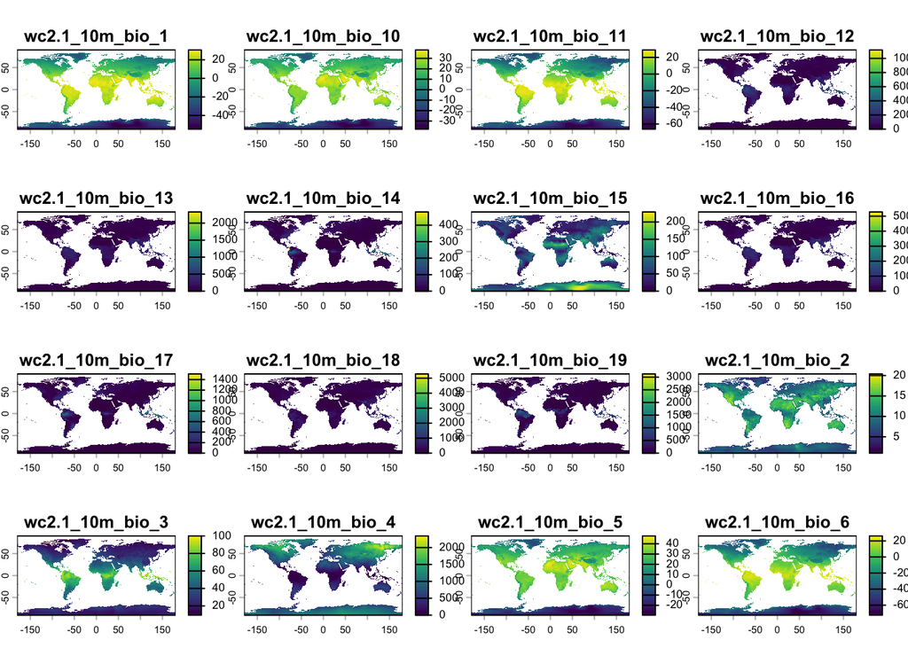

```r
clim_files <- list.files("data/bioclim/", pattern = ".tif$", full.names = TRUE)
clim <- rast(clim_files)

plot(clim)
```